# Assessment of Air Quality Models in Cities of India

Amy Lang(s2127213), Chen Yu Qi (17068721), Yeoh Li Tian(s2120306), Puveemalar Parameswaran(s2127371), Qi Han(s2123517)

18/5/2022

# Introduction

High population expansion has driven rapid industrialization, urbanisation, and an increase in motor traffic, resulting in worsening of air quality throughout the decades. In recent years, India has ranked fifth among the world’s most polluted countries, with a pollution index of 58.1. Furthermore, in emerging countries like India, the lack of effective enforcement of environmental legislation has only exacerbated pollution problems. As a result, evaluating air quality models in Indian cities is crucial since it allows for the identification of existing and future air pollution effects. Hence, the data set regarding Air Quality in India collected from 1990-2015 is been analysed to display the city with lowest air quality among the cities of India.

# Objective

1. To describe the history of movement of air air pollutant with time.
2. To develop clustering which is unsupervised machine learning technique to identify cities (location) with similar air quality.
3. To develop a time series regression model for prediction.

# Data Preprocessing with Exploratory Data Analysis (EDA)

We utilize the India Air Quality Data from Kaggle. https://www.kaggle.com/datasets/shrutibhargava94/india-air-quality-data

## Load Libraries

```r
library(ggplot2)
library(dplyr)
library(scales)
library(grid)
library(tidyr)
library(rstudioapi)
library(tidyverse)
library(lubridate,magrittr)
library(ggfortify)
library(tseries)
library('vars')
library('quantmod')
library(forecast)
```

## Load Dataset

```r
main_dir<- dirname(dirname(rstudioapi::getSourceEditorContext()$path))
datadir<- paste0(main_dir,"/data")
data_path<- paste0(datadir,"/data.csv")
figdir<-paste0(main_dir, "/figures")

df=read.csv(data_path)
head(df)
```

```
##   stn_code      sampling_date          state  location agency
## 1      150 February - M021990 Andhra Pradesh Hyderabad   <NA>
## 2      151 February - M021990 Andhra Pradesh Hyderabad   <NA>
## 3      152 February - M021990 Andhra Pradesh Hyderabad   <NA>
## 4      150    March - M031990 Andhra Pradesh Hyderabad   <NA>
## 5      151    March - M031990 Andhra Pradesh Hyderabad   <NA>
## 6      152    March - M031990 Andhra Pradesh Hyderabad   <NA>
##                                 type so2  no2 rspm spm
## 1 Residential, Rural and other Areas 4.8 17.4   NA  NA
## 2                    Industrial Area 3.1  7.0   NA  NA
## 3 Residential, Rural and other Areas 6.2 28.5   NA  NA
## 4 Residential, Rural and other Areas 6.3 14.7   NA  NA
## 5                    Industrial Area 4.7  7.5   NA  NA
## 6 Residential, Rural and other Areas 6.4 25.7   NA  NA
##   location_monitoring_station pm2_5       date
## 1                        <NA>    NA 1990-02-01
## 2                        <NA>    NA 1990-02-01
## 3                        <NA>    NA 1990-02-01
## 4                        <NA>    NA 1990-03-01
## 5                        <NA>    NA 1990-03-01
## 6                        <NA>    NA 1990-03-01
```

## Explore Dataset

```r
str(df)
```

```
## 'data.frame':    435742 obs. of  13 variables:
##  $ stn_code                   : chr  "150" "151" "152" "150" ...
##  $ sampling_date              : chr  "February - M021990" "February - M021990" "February - M021990" "March - M031990" ...
##  $ state                      : chr  "Andhra Pradesh" "Andhra Pradesh" "Andhra Pradesh" "Andhra Pradesh" ...
##  $ location                   : chr  "Hyderabad" "Hyderabad" "Hyderabad" "Hyderabad" ...
##  $ agency                     : chr  NA NA NA NA ...
##  $ type                       : chr  "Residential, Rural and other Areas" "Industrial Area" "Residential, Rural and other Areas" "Residential, Rural and other Areas" ...
##  $ so2                        : num  4.8 3.1 6.2 6.3 4.7 6.4 5.4 4.7 4.2 4 ...
##  $ no2                        : num  17.4 7 28.5 14.7 7.5 25.7 17.1 8.7 23 8.9 ...
##  $ rspm                       : num  NA NA NA NA NA NA NA NA NA NA ...
##  $ spm                        : num  NA NA NA NA NA NA NA NA NA NA ...
##  $ location_monitoring_station: chr  NA NA NA NA ...
##  $ pm2_5                      : num  NA NA NA NA NA NA NA NA NA NA ...
##  $ date                       : chr  "1990-02-01" "1990-02-01" "1990-02-01" "1990-03-01" ...
```

There are 13 variables and 435742 row of observations in total.

```r
summary(df)
```

```
##    stn_code         sampling_date         state             location
##  Length:435742      Length:435742      Length:435742      Length:435742
##  Class :character   Class :character   Class :character   Class :character
##  Mode  :character   Mode  :character   Mode  :character   Mode  :character
##
##
##
##
##     agency              type                so2              no2
##  Length:435742      Length:435742      Min.   :  0.00   Min.   :  0.00
##  Class :character   Class :character   1st Qu.:  5.00   1st Qu.: 14.00
##  Mode  :character   Mode  :character   Median :  8.00   Median : 22.00
##                                        Mean   : 10.83   Mean   : 25.81
##                                        3rd Qu.: 13.70   3rd Qu.: 32.20
##                                        Max.   :909.00   Max.   :876.00
##                                        NA's   :34646    NA's   :16233
##       rspm             spm         location_monitoring_station     pm2_5
##  Min.   :   0.0   Min.   :   0.0   Length:435742               Min.   :  3.0
##  1st Qu.:  56.0   1st Qu.: 111.0   Class :character            1st Qu.: 24.0
##  Median :  90.0   Median : 187.0   Mode  :character            Median : 32.0
##  Mean   : 108.8   Mean   : 220.8                               Mean   : 40.8
##  3rd Qu.: 142.0   3rd Qu.: 296.0                               3rd Qu.: 46.0
##  Max.   :6307.0   Max.   :3380.0                               Max.   :504.0
##  NA's   :40222    NA's   :237387                               NA's   :426428
##      date
##  Length:435742
##  Class :character
##  Mode  :character
##
##
##
##
```

Stn_code, sampling_date, state, location, agency, type, location_monitoring_station and date is labelled as character variables.

so2,no2,rspm,spm and pm2_5 are numerical variables with missing values.

## Drop Unnecessary Variables

Since “sampling_date” carry same meaning as “date”, we may drop it.

stn_code, agency and location_monitoring_station also seen carry same meaning with state, we may drop it too.

```r
df$sampling_date=NULL
df$stn_code=NULL
df$agency=NULL
df$location_monitoring_station=NULL
head(df)
```

```
##            state  location                               type so2  no2 rspm spm
## 1 Andhra Pradesh Hyderabad Residential, Rural and other Areas 4.8 17.4   NA  NA
## 2 Andhra Pradesh Hyderabad                    Industrial Area 3.1  7.0   NA  NA
## 3 Andhra Pradesh Hyderabad Residential, Rural and other Areas 6.2 28.5   NA  NA
## 4 Andhra Pradesh Hyderabad Residential, Rural and other Areas 6.3 14.7   NA  NA
## 5 Andhra Pradesh Hyderabad                    Industrial Area 4.7  7.5   NA  NA
## 6 Andhra Pradesh Hyderabad Residential, Rural and other Areas 6.4 25.7   NA  NA
##   pm2_5       date
## 1    NA 1990-02-01
## 2    NA 1990-02-01
## 3    NA 1990-02-01
## 4    NA 1990-03-01
## 5    NA 1990-03-01
## 6    NA 1990-03-01
```

## Exploratory Data Analysis - Univariate

Let’s observe the variables one by one.

### Categorical variable - State

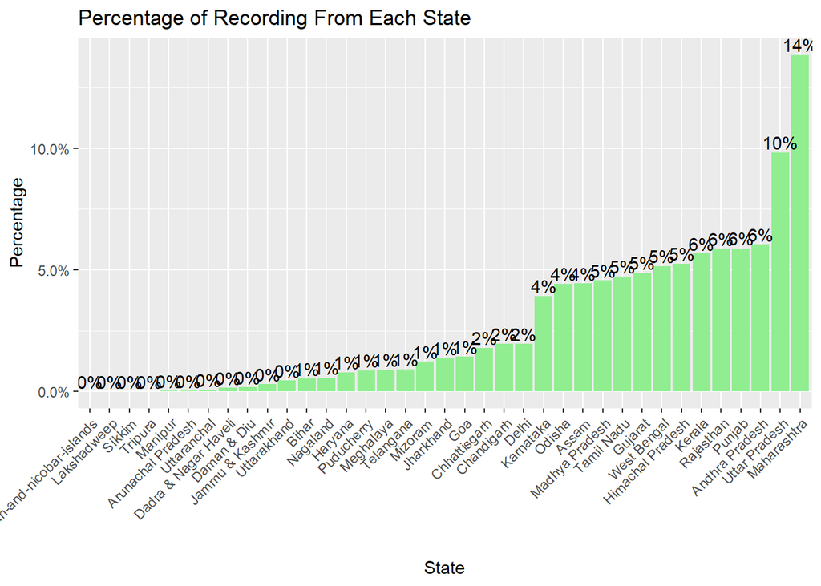

```r
plotdata <- df %>%
  count(state) %>%
  mutate(pct = n / sum(n),
         pctlabel = paste0(round(pct*100), "%"))
ggplot(plotdata, aes(x=reorder(state, n),y=pct)) +
  geom_bar(stat = "identity", fill = "lightgreen") +
  geom_text(aes(label = pctlabel), vjust = -0.25) +
  theme(axis.text.x = element_text(angle = 45, hjust = 1))+
  scale_y_continuous(labels = percent) +
  labs(y = "Percentage",x="State", title = "Percentage of Recording From Each State")
```

Maharashtra have most observations followed by Uttar Pradesh and others.

### Categorical variable - Location

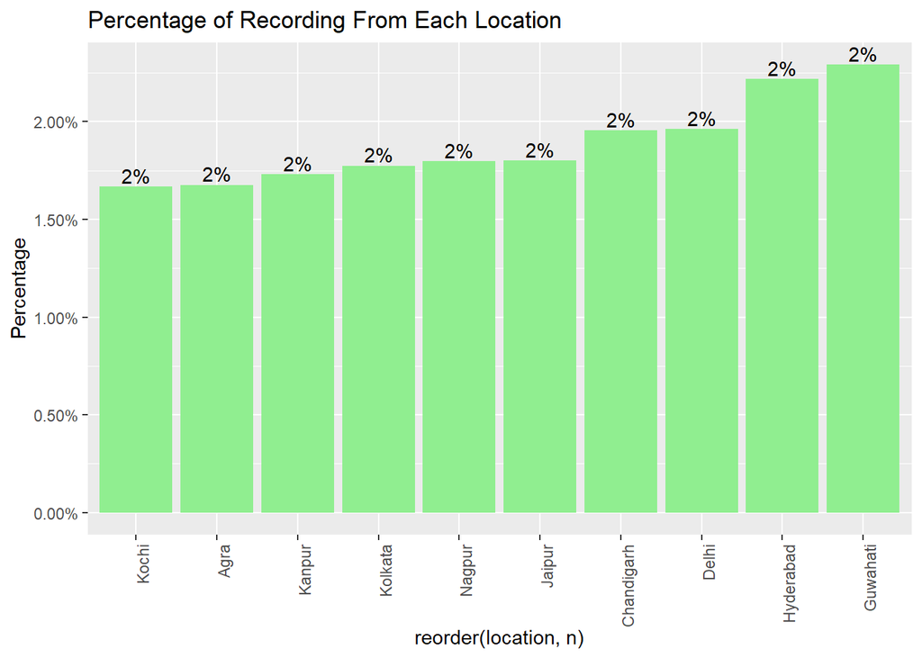

```r
plotdata <- df %>%
  count(location) %>%
  mutate(pct = n / sum(n),
         pctlabel = paste0(round(pct*100), "%")) %>%
  arrange(desc(n)) %>%
  head(10)
ggplot(plotdata, aes(x = reorder(location, n),y=pct)) +
  geom_bar(stat = "identity", fill = "lightgreen") +
  geom_text(aes(label = pctlabel), vjust = -0.25) +
  theme(axis.text.x = element_text(angle = 90, hjust = 1))+
  scale_y_continuous(labels = percent) +
  labs(y = "Percentage", title = "Percentage of Recording From Each Location")
```

Top 10 recording location is displayed. Guwahati have the highest percentage of recording.

### Categorical variable - Type

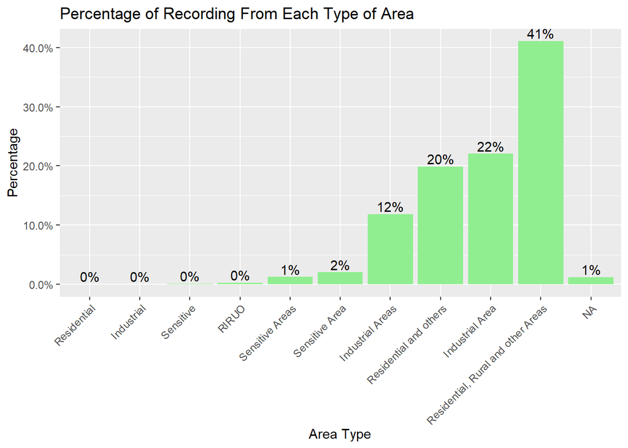

```r
plotdata <- df %>%
  count(type) %>%
  mutate(pct = n / sum(n),
         pctlabel = paste0(round(pct*100), "%"))
ggplot(plotdata, aes(x = reorder(type, n), y=pct)) +
  geom_bar(stat = "identity", fill = "lightgreen") +
  geom_text(aes(label = pctlabel), vjust = -0.25) +
  theme(axis.text.x = element_text(angle = 45, hjust = 1))+
  scale_y_continuous(labels = percent) +
  labs(y = "Percentage", x="Area Type", title = "Percentage of Recording From Each Type of Area")
```

There are many group carrying repetitive meaning, we can group the data into “residual”, “industrial” and “others” class.

```r
df$type[df$type %in% "Residential, Rural and other Areas"] <- "Residential"
df$type[df$type %in% "Residential and others"] <- "Residential"
df$type[df$type %in% "Industrial Area"] <- "Industrial"
df$type[df$type %in% "Industrial Areas"] <- "Industrial"
df$type[df$type %in% "RIRUO"] <- "Others"
df$type[df$type %in% "Sensitive"] <- "Others"
df$type[df$type %in% "Sensitive Areas"] <- "Others"
df$type[df$type %in% "Sensitive Area"] <- "Others"
df$type[is.na(df$type)]= "Others"
```

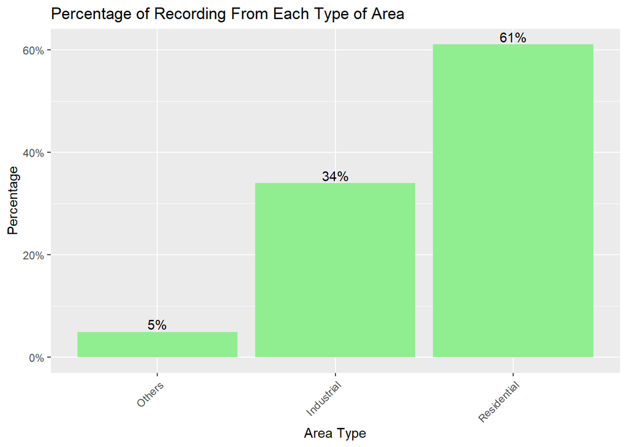

```r
plotdata <- df %>%
  count(type) %>%
  mutate(pct = n / sum(n),
         pctlabel = paste0(round(pct*100), "%"))

p1<-ggplot(plotdata, aes(x = reorder(type, n), y=pct)) +
  geom_bar(stat = "identity", fill = "lightgreen") +
  geom_text(aes(label = pctlabel), vjust = -0.25) +
  theme(axis.text.x = element_text(angle = 45, hjust = 1))+
  scale_y_continuous(labels = percent) +
  labs(y = "Percentage", x="Area Type", title = "Percentage of Recording From Each Type of Area")
p1
```

### 4. Numerical Vairable - Sulfur dioxide (so2), Nitrogen dioxide (no2), Respirable Suspended Particulate Matter (rspm), Suspended particulate matter (spm), Fine particulate matter (pm2.5)

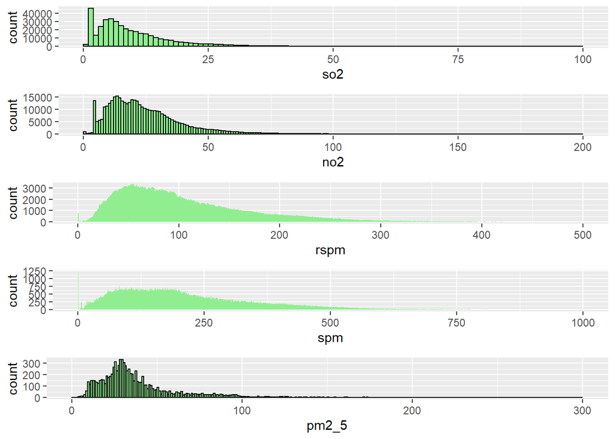

```r
plot1=ggplot(df, aes(x = so2)) +
  geom_histogram(binwidth=0.1, breaks= seq(0,100), colour="black", fill = "lightgreen")
plot2=ggplot(df, aes(x = no2)) +
  geom_histogram(binwidth=1, breaks= seq(0,200),colour="black", fill = "lightgreen")
plot3=ggplot(df, aes(x = rspm)) +
  geom_histogram(binwidth=100,  breaks= seq(0,500), fill = "lightgreen")
plot4=ggplot(df, aes(x = spm)) +
  geom_histogram(binwidth=100, breaks= seq(0,1000) ,fill = "lightgreen")
plot5=ggplot(df, aes(x = pm2_5)) +
  geom_histogram(binwidth=0.5, breaks= seq(0,300), colour="black", fill = "lightgreen")
grid.newpage()
vplayout <- function(x, y) viewport(layout.pos.row = x, layout.pos.col = y)
pushViewport(viewport(layout = grid.layout(5, 1)))
print(plot1, vp = vplayout(1, 1))
print(plot2, vp = vplayout(2, 1))
print(plot3, vp = vplayout(3, 1))
print(plot4, vp = vplayout(4, 1))
print(plot5, vp = vplayout(5, 1))
```

We can observe that all so2, no2, rspm, spm and pm2_5 is right skewed, data scattered around lower value.

## Creating clean data set for multivariate EDA

```r
df_c=df
data_c_path = paste0(datadir, "/data_c.csv")

df_c$pm2_5=NULL
df_c$date=NULL
head(df_c)
```

```
##            state  location        type so2  no2 rspm spm
## 1 Andhra Pradesh Hyderabad Residential 4.8 17.4   NA  NA
## 2 Andhra Pradesh Hyderabad  Industrial 3.1  7.0   NA  NA
## 3 Andhra Pradesh Hyderabad Residential 6.2 28.5   NA  NA
## 4 Andhra Pradesh Hyderabad Residential 6.3 14.7   NA  NA
## 5 Andhra Pradesh Hyderabad  Industrial 4.7  7.5   NA  NA
## 6 Andhra Pradesh Hyderabad Residential 6.4 25.7   NA  NA
```

We dropped pm2.5 because it is the target variable and it is only available for last 2 year. We dropped date because clustering model no need time variable.

### Cleaning missing Values

```r
for(i in 1:7){
  x=sum(is.na(df_c[i]))
  print(paste(names(df_c[i]),x))}
```

```
## [1] "state 0"
## [1] "location 3"
## [1] "type 0"
## [1] "so2 34646"
## [1] "no2 16233"
## [1] "rspm 40222"
## [1] "spm 237387"
```

There are 34646 rows of missing value in “so2”, 16233 rows of missing value in “no2”, 40222 rows of missing value in “rspm”, 237387 rows of missing value in “spm”, 426428 rows of missing value in “pm2_5”.

```r
df_c$so2[is.na(df_c$so2)]= mean(df_c$so2, na.rm = TRUE)
df_c$no2[is.na(df_c$no2)]= mean(df_c$no2, na.rm = TRUE)
df_c$rspm[is.na(df_c$rspm)]= mean(df_c$rspm, na.rm = TRUE)
df_c$spm[is.na(df_c$spm)]= mean(df_c$spm, na.rm = TRUE)
df_c <- df_c %>% na.omit(df_c)

for(i in 1:7){
  x=sum(is.na(df_c[i]))
  print(paste(names(df_c[i]),x))}
```

```
## [1] "state 0"
## [1] "location 0"
## [1] "type 0"
## [1] "so2 0"
## [1] "no2 0"
## [1] "rspm 0"
## [1] "spm 0"
```

We mutate missing value in numerical variable using mean. 3 missing value for location, we just drop. There is no more missing values in the dataset, it is ready to export.

```r
head(df_c)
```

```
##            state  location        type so2  no2     rspm      spm
## 1 Andhra Pradesh Hyderabad Residential 4.8 17.4 108.8328 220.7835
## 2 Andhra Pradesh Hyderabad  Industrial 3.1  7.0 108.8328 220.7835
## 3 Andhra Pradesh Hyderabad Residential 6.2 28.5 108.8328 220.7835
## 4 Andhra Pradesh Hyderabad Residential 6.3 14.7 108.8328 220.7835
## 5 Andhra Pradesh Hyderabad  Industrial 4.7  7.5 108.8328 220.7835
## 6 Andhra Pradesh Hyderabad Residential 6.4 25.7 108.8328 220.7835
```

```r
str(df_c)
```

```
## 'data.frame':    435739 obs. of  7 variables:
##  $ state   : chr  "Andhra Pradesh" "Andhra Pradesh" "Andhra Pradesh" "Andhra Pradesh" ...
##  $ location: chr  "Hyderabad" "Hyderabad" "Hyderabad" "Hyderabad" ...
##  $ type    : chr  "Residential" "Industrial" "Residential" "Residential" ...
##  $ so2     : num  4.8 3.1 6.2 6.3 4.7 6.4 5.4 4.7 4.2 4 ...
##  $ no2     : num  17.4 7 28.5 14.7 7.5 25.7 17.1 8.7 23 8.9 ...
##  $ rspm    : num  109 109 109 109 109 ...
##  $ spm     : num  221 221 221 221 221 ...
##  - attr(*, "na.action")= 'omit' Named int [1:3] 435740 435741 435742
##   ..- attr(*, "names")= chr [1:3] "435740" "435741" "435742"
```

### Export subset if needed

```r
#data_c_path = paste0(datadir, "/data_c.csv")
#write.csv(df_c, data_c_path, row.names=FALSE)
```

### Exploratory Data Analysis - Multivariate

### 1. Correlation

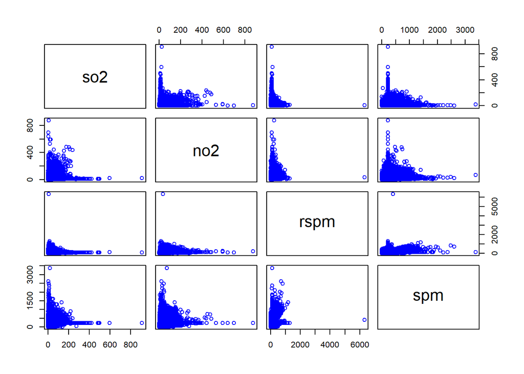

```r
#pairs(~ so2 + no2 + rspm + spm, data=df_c, col = 'blue')
#plot(df_c)
fig1_path<- paste0(figdir,"/plot correlation-1.png")
fig2_path<- paste0(figdir,"/plot correlation-2.png")
knitr::include_graphics(fig1_path)
```

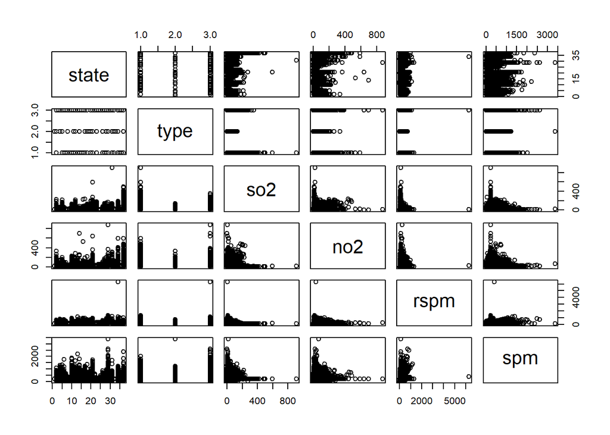

```r
knitr::include_graphics(fig2_path)
```

so2 and no2 seem to have slightly positive relationship and same for rspm and spm, while the others variables seem like having poor relationship.

### 2. Bivarite plot

#### Numerical variables with state

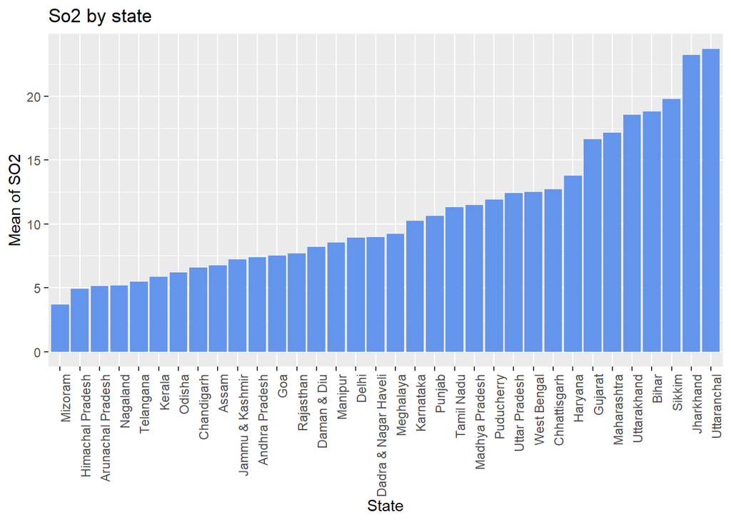

```r
plotdata <- df_c %>%
  group_by(state) %>%
  summarize(mean_1 = mean(so2))
ggplot(plotdata, aes(x = reorder(state, mean_1), y = mean_1)) +
  geom_bar(stat = "identity", fill = "cornflowerblue") +
  theme(axis.text.x = element_text(angle = 90, hjust = 1))+
  labs(title = "So2 by state", y = "Mean of SO2", x ="State")
```

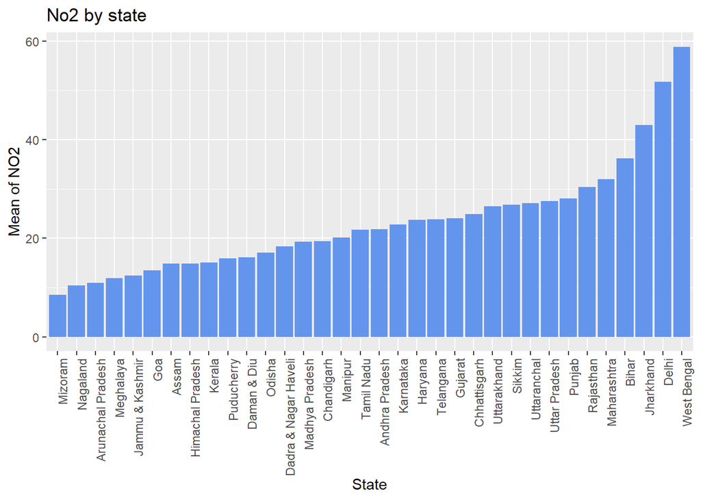

```r
plotdata <- df_c %>%
  group_by(state) %>%
  summarize(mean_1 = mean(no2))
ggplot(plotdata, aes(x = reorder(state, mean_1), y = mean_1)) +
  geom_bar(stat = "identity", fill = "cornflowerblue") +
  theme(axis.text.x = element_text(angle = 90, hjust = 1))+
  labs(title = "No2 by state", y = "Mean of NO2", x ="State")
```

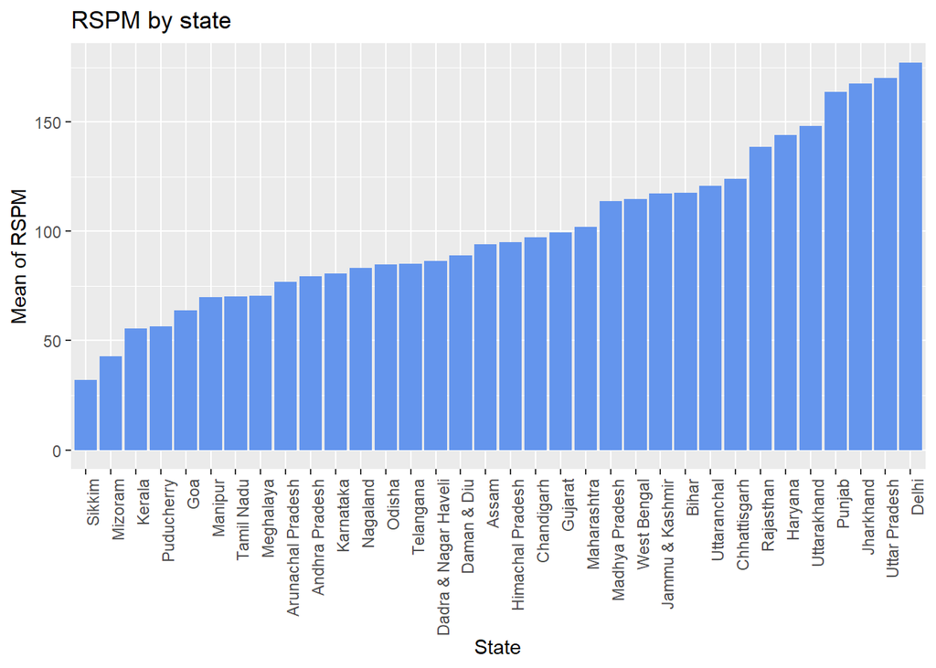

```r
plotdata <- df_c  %>%
  group_by(state) %>%
  summarize(mean_1 = mean(rspm))
ggplot(plotdata, aes(x = reorder(state, mean_1), y = mean_1)) +
  geom_bar(stat = "identity", fill = "cornflowerblue") +
  theme(axis.text.x = element_text(angle = 90, hjust = 1))+
  labs(title = "RSPM by state", y = "Mean of RSPM", x ="State")
```

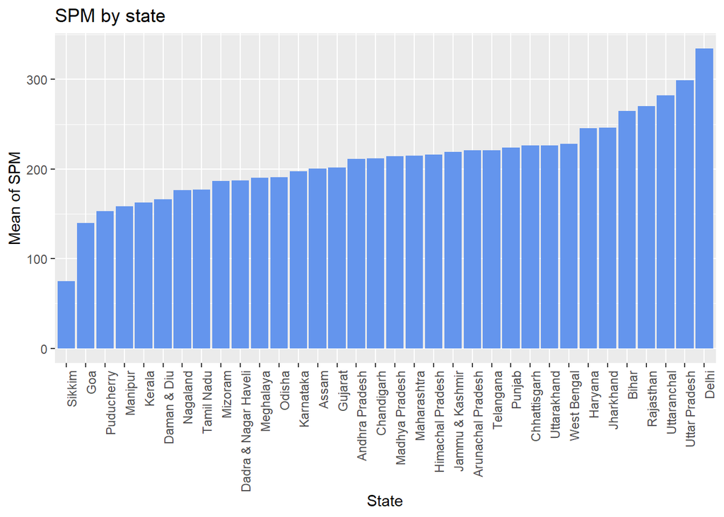

```r
plotdata <- df_c  %>%
  group_by(state) %>%
  summarize(mean_1 = mean(spm))
ggplot(plotdata, aes(x = reorder(state, mean_1), y = mean_1)) +
  geom_bar(stat = "identity", fill = "cornflowerblue") +
  theme(axis.text.x = element_text(angle = 90, hjust = 1))+
  labs(title = "SPM by state", y = "Mean of SPM", x ="State")
```

Uttarachai have the highest SO2 concentration in the air. West Bengal have the highest NO2 concentration in the air. Delhi have the highest RSPM index and SPM index.

#### Numerical variables with type

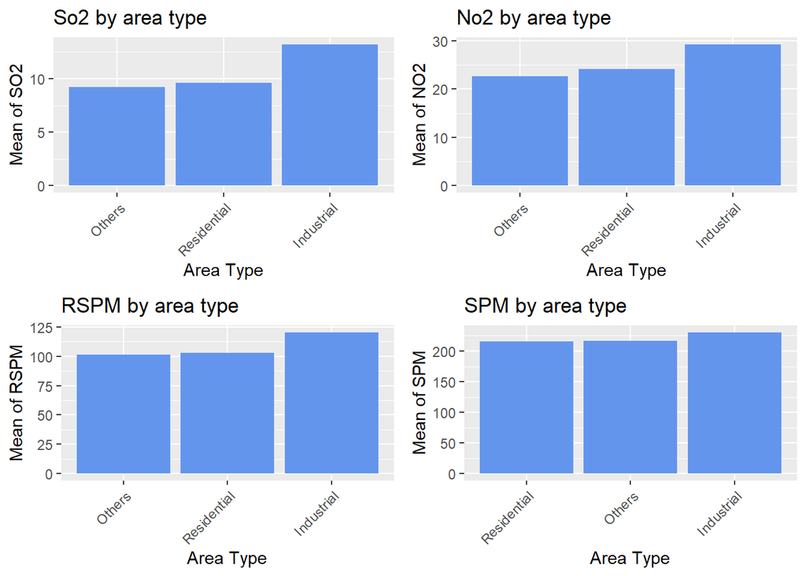

```r
plotdata <- df_c %>%
  group_by(type) %>%
  summarize(mean_1 = mean(so2))
plot1=ggplot(plotdata, aes(x = reorder(type, mean_1), y = mean_1)) +
  geom_bar(stat = "identity", fill = "cornflowerblue") +
  theme(axis.text.x = element_text(angle = 45, hjust = 1))+
  labs(title = "So2 by area type", y = "Mean of SO2", x ="Area Type")

plotdata <- df_c %>%
  group_by(type) %>%
  summarize(mean_1 = mean(no2))
plot2=ggplot(plotdata, aes(x = reorder(type, mean_1), y = mean_1)) +
  geom_bar(stat = "identity", fill = "cornflowerblue") +
  theme(axis.text.x = element_text(angle = 45, hjust = 1))+
  labs(title = "No2 by area type", y = "Mean of NO2", x ="Area Type")

plotdata <- df_c %>%
  group_by(type) %>%
  summarize(mean_1 = mean(rspm))
plot3=ggplot(plotdata, aes(x = reorder(type, mean_1), y = mean_1)) +
  geom_bar(stat = "identity", fill = "cornflowerblue") +
  theme(axis.text.x = element_text(angle = 45, hjust = 1))+
  labs(title = "RSPM by area type", y = "Mean of RSPM", x ="Area Type")

plotdata <- df_c %>%
  group_by(type) %>%
  summarize(mean_1 = mean(spm))
plot4=ggplot(plotdata, aes(x = reorder(type, mean_1), y = mean_1)) +
  geom_bar(stat = "identity", fill = "cornflowerblue") +
  theme(axis.text.x = element_text(angle = 45, hjust = 1))+
  labs(title = "SPM by area type", y = "Mean of SPM", x ="Area Type")
grid.newpage()
pushViewport(viewport(layout = grid.layout(2, 2)))
print(plot1, vp = vplayout(1, 1))
print(plot2, vp = vplayout(1, 2))
print(plot3, vp = vplayout(2, 1))
print(plot4, vp = vplayout(2, 2))
```

Industrial area have highest So2 concentration, No2 concentration, RSPM index and SPM index.

## Preprocessing for Time Series Regression Model

### Create Subset for Time Series Regression Model

From the original data set, we also produce a clean data for time series regression purposes. The goal is to create a data set for predicting pm2.5 using the data from year 2014 and 2015.

```r
data=subset(df, !is.na(pm2_5))
head(data)
```

```
##                      state location       type so2 no2 rspm spm pm2_5
## 65037 Dadra & Nagar Haveli  Khadoli Industrial  18  31  104  NA    35
## 65038 Dadra & Nagar Haveli  Khadoli Industrial  14  26   94  NA    32
## 65039 Dadra & Nagar Haveli  Khadoli Industrial  16  28   99  NA    35
## 65040 Dadra & Nagar Haveli  Khadoli Industrial  13  23   82  NA    24
## 65041 Dadra & Nagar Haveli  Khadoli Industrial  14  29   93  NA    32
## 65042 Dadra & Nagar Haveli  Khadoli Industrial  13  25   77  NA    22
##             date
## 65037 2015-08-06
## 65038 2015-08-10
## 65039 2015-08-13
## 65040 2015-08-20
## 65041 2015-08-24
## 65042 2015-08-26
```

```r
str(data)
```

```
## 'data.frame':    9314 obs. of  9 variables:
##  $ state   : chr  "Dadra & Nagar Haveli" "Dadra & Nagar Haveli" "Dadra & Nagar Haveli" "Dadra & Nagar Haveli" ...
##  $ location: chr  "Khadoli" "Khadoli" "Khadoli" "Khadoli" ...
##  $ type    : chr  "Industrial" "Industrial" "Industrial" "Industrial" ...
##  $ so2     : num  18 14 16 13 14 13 12 15 14 16 ...
##  $ no2     : num  31 26 28 23 29 25 21 26 25 26 ...
##  $ rspm    : num  104 94 99 82 93 77 81 90 89 100 ...
##  $ spm     : num  NA NA NA NA NA NA NA NA NA NA ...
##  $ pm2_5   : num  35 32 35 24 32 22 27 29 27 34 ...
##  $ date    : chr  "2015-08-06" "2015-08-10" "2015-08-13" "2015-08-20" ...
```

There is only 9314 rows that have pm2.5 value.

### Cleaning Missing Values

```r
for(i in 1:9){
  x=sum(is.na(data[i]))
  print(paste(names(data[i]),x))}
```

```
## [1] "state 0"
## [1] "location 0"
## [1] "type 0"
## [1] "so2 119"
## [1] "no2 96"
## [1] "rspm 60"
## [1] "spm 9314"
## [1] "pm2_5 0"
## [1] "date 0"
```

so2,no2,rspm have missing values. spm is blank.

```r
data$so2[is.na(data$so2)]= mean(data$so2, na.rm = TRUE)
data$no2[is.na(data$no2)]= mean(data$no2, na.rm = TRUE)
data$rspm[is.na(data$rspm)]= mean(data$rspm, na.rm = TRUE)
data$spm=NULL

for(i in 1:8){
  x=sum(is.na(data[i]))
  print(paste(names(data[i]),x))}
```

```
## [1] "state 0"
## [1] "location 0"
## [1] "type 0"
## [1] "so2 0"
## [1] "no2 0"
## [1] "rspm 0"
## [1] "pm2_5 0"
## [1] "date 0"
```

There is no missing value now and we can export this subset out for further enhancement such as visualization, modifications and modelling depending on the requirement of time series modelling.

### Rearrange According To Date

```r
data$date<-as.Date(data$date, "%Y-%m-%d")
data=data[(order(data$date,decreasing=FALSE)),]
```

### Export Subset if needed

```r
#write.csv(data,"data_ts.csv", row.names=FALSE)
```

### Time Series Plot

```r
#check the data of noPmNA
table(data$state)
```

```
##
## Dadra & Nagar Haveli          Daman & Diu                Delhi
##                   43                   44                  371
##                  Goa              Gujarat       Madhya Pradesh
##                 1390                 2401                  829
##               Odisha           Tamil Nadu            Telangana
##                 2788                  454                  354
##          West Bengal
##                  640
```

```r
#split the dataset
splitByState <- split(data, data$state)
str(splitByState)
```

```
## List of 10
##  $ Dadra & Nagar Haveli:'data.frame':    43 obs. of  8 variables:
##   ..$ state   : chr [1:43] "Dadra & Nagar Haveli" "Dadra & Nagar Haveli" "Dadra & Nagar Haveli" "Dadra & Nagar Haveli" ...
##   ..$ location: chr [1:43] "Khadoli" "Khadoli" "Khadoli" "Khadoli" ...
##   ..$ type    : chr [1:43] "Industrial" "Industrial" "Industrial" "Industrial" ...
##   ..$ so2     : num [1:43] 18 14 16 13 14 13 12 15 14 16 ...
##   ..$ no2     : num [1:43] 31 26 28 23 29 25 21 26 25 26 ...
##   ..$ rspm    : num [1:43] 104 94 99 82 93 77 81 90 89 100 ...
##   ..$ pm2_5   : num [1:43] 35 32 35 24 32 22 27 29 27 34 ...
##   ..$ date    : Date[1:43], format: "2015-08-06" "2015-08-10" ...
##  $ Daman & Diu         :'data.frame':    44 obs. of  8 variables:
##   ..$ state   : chr [1:44] "Daman & Diu" "Daman & Diu" "Daman & Diu" "Daman & Diu" ...
##   ..$ location: chr [1:44] "Daman" "Daman" "Daman" "Daman" ...
##   ..$ type    : chr [1:44] "Industrial" "Industrial" "Industrial" "Industrial" ...
##   ..$ so2     : num [1:44] 12 14 14 12 13 14 13 12 13 14 ...
##   ..$ no2     : num [1:44] 22 24 26 21 23 25 22 21 23 25 ...
##   ..$ rspm    : num [1:44] 94 90 73 81 76 89 93 87 87 89 ...
##   ..$ pm2_5   : num [1:44] 30 28 23 22 28 27 30 26 29 28 ...
##   ..$ date    : Date[1:44], format: "2015-08-06" "2015-08-10" ...
##  $ Delhi               :'data.frame':    371 obs. of  8 variables:
##   ..$ state   : chr [1:371] "Delhi" "Delhi" "Delhi" "Delhi" ...
##   ..$ location: chr [1:371] "Delhi" "Delhi" "Delhi" "Delhi" ...
##   ..$ type    : chr [1:371] "Industrial" "Residential" "Industrial" "Residential" ...
##   ..$ so2     : num [1:371] 4 4 4 4 4 4 4 4 4 4 ...
##   ..$ no2     : num [1:371] 67 35 55 51 61 47 38 65 57 61 ...
##   ..$ rspm    : num [1:371] 397 221 250 192 289 143 171 344 197 425 ...
##   ..$ pm2_5   : num [1:371] 110 141 155 86 151 62 139 163 126 147 ...
##   ..$ date    : Date[1:371], format: "2015-01-01" "2015-01-05" ...
##  $ Goa                 :'data.frame':    1390 obs. of  8 variables:
##   ..$ state   : chr [1:1390] "Goa" "Goa" "Goa" "Goa" ...
##   ..$ location: chr [1:1390] "Curchorem" "Margao" "Mapusa" "Ponda" ...
##   ..$ type    : chr [1:1390] "Residential" "Residential" "Residential" "Residential" ...
##   ..$ so2     : num [1:1390] 4 5 9 4 4 15 4 4 5 4 ...
##   ..$ no2     : num [1:1390] 9 9 11 9 9 9 8 9 10 9 ...
##   ..$ rspm    : num [1:1390] 70 94 72 60 68 77 44 77 88 63 ...
##   ..$ pm2_5   : num [1:1390] 27 35 36 24 25 29 13 28 34 22 ...
##   ..$ date    : Date[1:1390], format: "2015-01-02" "2015-01-02" ...
##  $ Gujarat             :'data.frame':    2401 obs. of  8 variables:
##   ..$ state   : chr [1:2401] "Gujarat" "Gujarat" "Gujarat" "Gujarat" ...
##   ..$ location: chr [1:2401] "Jamnagar" "Ahmedabad" "Ahmedabad" "Ahmedabad" ...
```

[output cut: 36 more lines]

```
##   ..$ type    : chr [1:354] "Industrial" "Industrial" "Industrial" "Industrial" ...
##   ..$ so2     : num [1:354] 1.8 12.4 2.8 8.7 2 0.3 3.4 3.03 3.5 6.5 ...
##   ..$ no2     : num [1:354] 66.3 86.3 38.4 55.4 46.1 62.2 44.8 31.5 26.1 45.3 ...
##   ..$ rspm    : num [1:354] 99 149 51 128 33 105 100 33 21 106 ...
##   ..$ pm2_5   : num [1:354] 54 78 24 56 20 35 24 10 6 49 ...
##   ..$ date    : Date[1:354], format: "2014-01-01" "2014-01-02" ...
##  $ West Bengal         :'data.frame':    640 obs. of  8 variables:
##   ..$ state   : chr [1:640] "West Bengal" "West Bengal" "West Bengal" "West Bengal" ...
##   ..$ location: chr [1:640] "Howrah" "Durgapur" "Kolkata" "Kolkata" ...
##   ..$ type    : chr [1:640] "Residential" "Residential" "Others" "Industrial" ...
##   ..$ so2     : num [1:640] 10 7 2 3 7 9 7 12 9 10 ...
##   ..$ no2     : num [1:640] 40 57 46 54 58 69 69 40 71 74 ...
##   ..$ rspm    : num [1:640] 138 82 77 104 86 93 214 132 217 92 ...
##   ..$ pm2_5   : num [1:640] 83 52 36 47 60 63 94 76 109 48 ...
##   ..$ date    : Date[1:640], format: "2015-01-02" "2015-01-02" ...
```

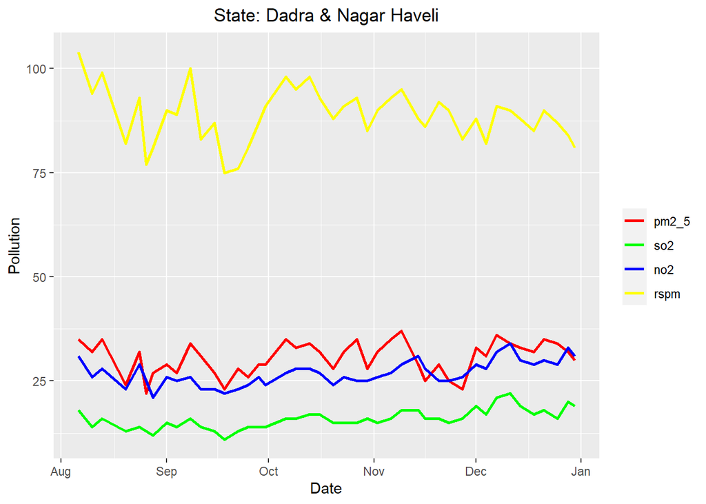

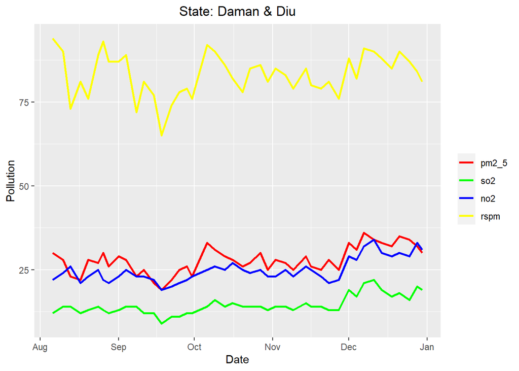

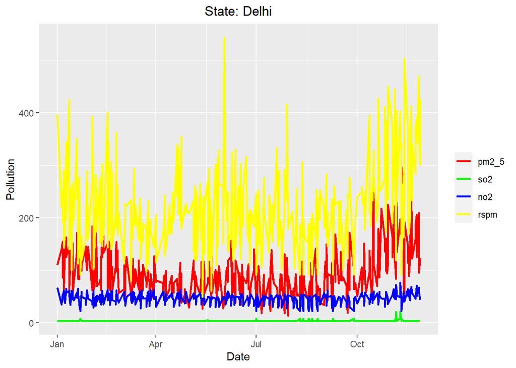

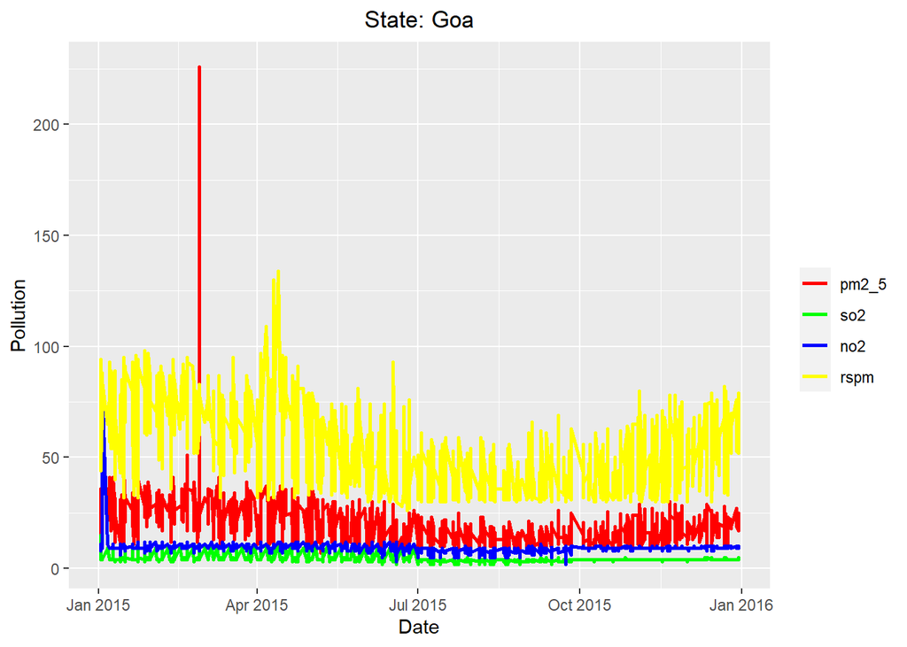

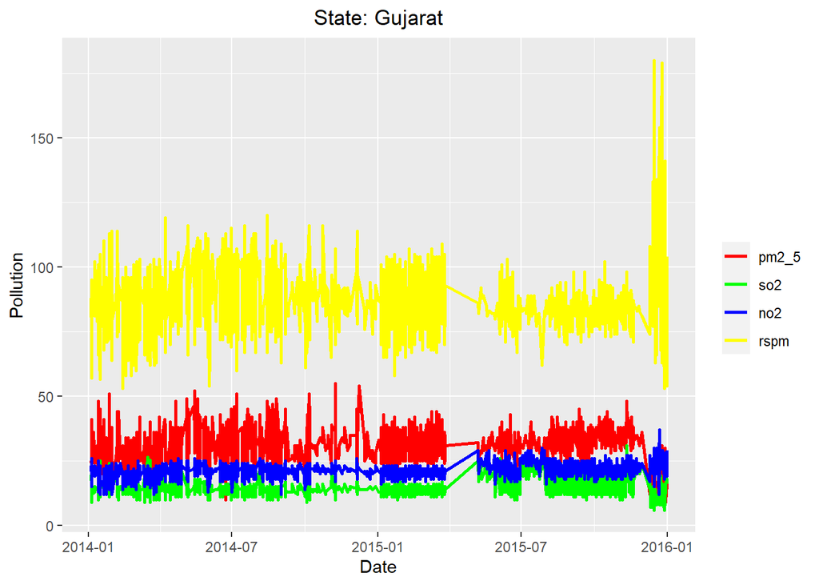

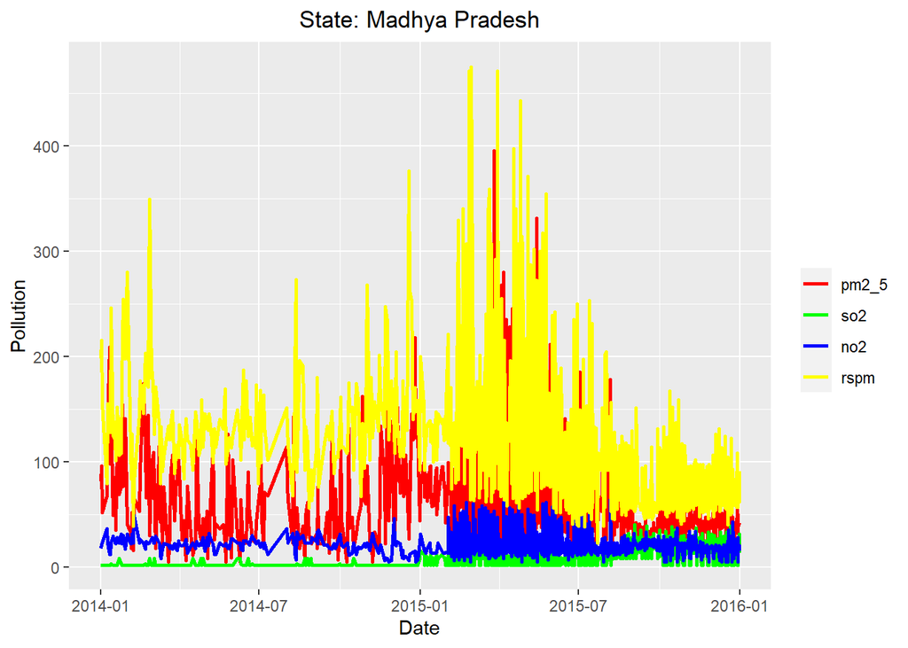

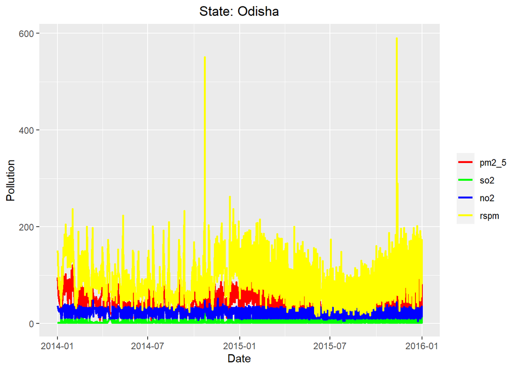

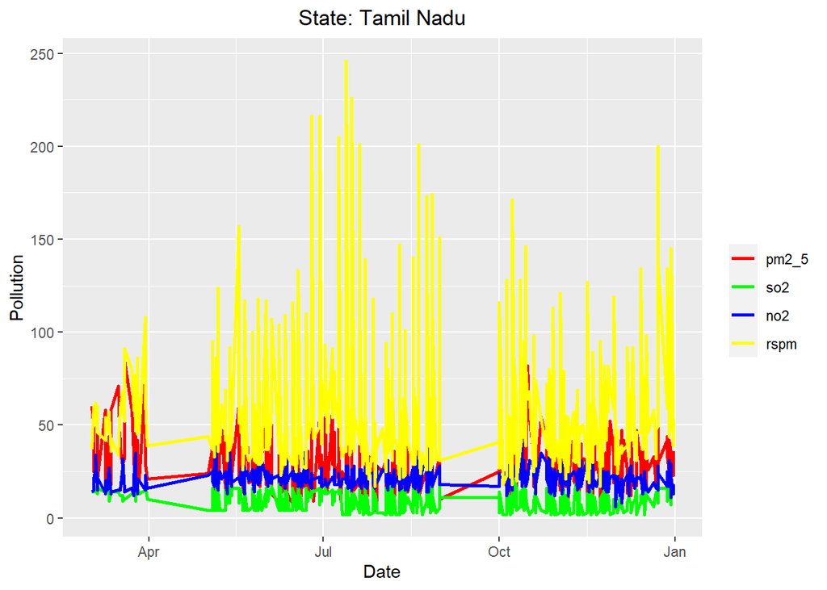

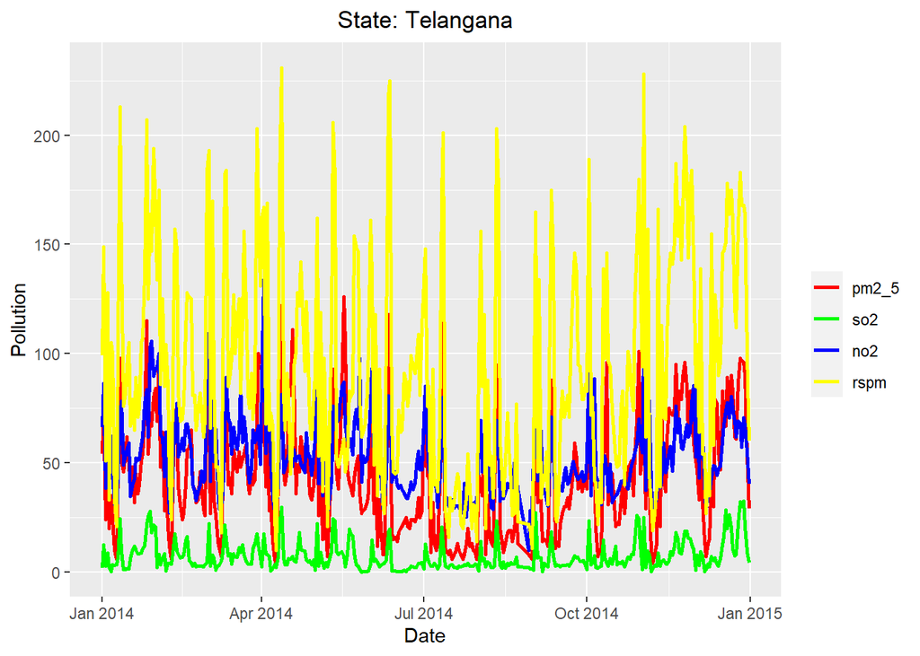

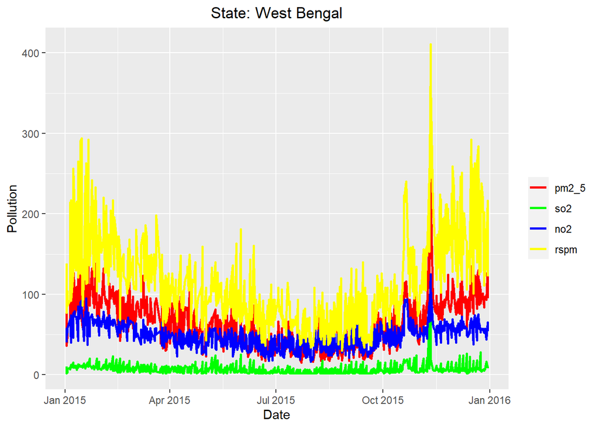

```r
library(ggplot2)

for (i in 1:length(splitByState)){
  loopdata<-splitByState[[i]]
  #print(loopdata)
  #print(as.character(names(splitByState[i])))
  #draw graph
  print(ggplot() +geom_line(data = loopdata,aes(x = date,y = pm2_5,colour = "pm2_5"),size=1) +
  geom_line(data = loopdata,aes(x = date,y = so2,colour = "so2"),size=1) +
  geom_line(data = loopdata,aes(x = date,y = no2,colour = "no2"),size=1) +
  geom_line(data = loopdata,aes(x = date,y = rspm,colour = "rspm"),size=1) +
  ggtitle(paste("State:",as.character(names(splitByState[i])))) +
  theme(plot.title = element_text(hjust = 0.5)) +
  scale_colour_manual("",values = c("pm2_5" = "red","so2"="green","no2"="blue","rspm"="yellow"))+
  xlab("Date")+ylab("Pollution"))
}
```